# Apple App Store - Preparando el dataset

En este notebook vamos a explorar, limpiar y preparar los datos de la App Store, para crear un nuevo dataset listo para analizar.

Hemos obtenido un dataset público bastante grande, publicado por el usuario de Kaggle [CMQUB](https://www.kaggle.com/cmqub19) .

https://www.kaggle.com/cmqub19/763k-ios-app-info/metadata

### Proceso de Data Cleaning - Objetivos

Básicamente, lo que haremos en este notebook será acondicionar los datos para poder analizarlos según nuestros propósitos. En el Pre-Análisis está explicado más en profundidad, pero básicamente lo que queremos es filtrar todas aquellas Apps que cumplan con los criterios establecidos por la empresa que nos encomendó el análisis. De esta manera, los datos resultantes crearán el entorno que debemos estudiar para encontrar la mejor solución para la empresa.

- 1) Concretamente, limpiaremos el dataset de manera que en los datos resultantes:
  - Todas las columnas del DataFrame sean relevantes para nuestro análisis
  - Todas las Apps sean gratuitas
  - Todas las Apps estén disponibles en inglés y/o castellano
  - Los datos sean perfectamente manipulables y visualizables (gestión de valores nulos, datos numéricos, fechas, etc.)
- 2) Una vez tengamos los datos de la manera deseada —listos para analizarlos— crearemos un nuevo archivo CSV con el dataset resultante, y lo guardaremos.
- 3) Haremos lo mismo con el dataset de Google, hasta que consigamos un archivo CSV limpio.
- 4) Una vez tengamos ambos datasets preparados, compararemos su estructura y decidiremos si los combinamos en uno solo o los estudiamos por separado. El resultado debería ser el mismo, pero actuaremos de la manera que menos ralentice o dificulte el análisis (esto lo veremos más adelante).

## Importaciones y configuración del Notebook

Vamos a importar las librerías necesarias, y a realizar pequeños ajustes en el Notebook para facilitar el trabajo y mejorar las visualizaciones.

En este notebook utilizaremos:

- Pandas para manipulación de datos
- Numpy para operaciones matemáticas
- Plotly, Matplotlib y Seaborn para visualización de datos

```python
import pandas as pd
import numpy as np
import seaborn as sns
import matplotlib.pyplot as plt
%matplotlib inline

pd.set_option('display.max_columns', None)

pd.options.mode.chained_assignment = None

from IPython.core.display import HTML
HTML("""
<style>
.output_png {
    display: table-cell;
    text-align: center;
    margin:auto;
}
.prompt
    display:none;
}
}
</style>
""")
```

# 1. Primeras visualizaciones de los datos , información y documentación

Sin más preámbulos, vamos a mostrar el aspecto de los datos que tenemos:

```python
# Cinco primeras filas del DataFrame
apple = pd.read_csv("../fat_data/763K_plus_IOS_Apps_Info.csv")
apple.head()
```

|  | _id | IOS_App_Id | Title | Developer_Name | Developer_IOS_Id | IOS_Store_Url | Seller_Official_Website | Age_Rating | Total_Average_Rating | Total_Number_of_Ratings | Average_Rating_For_Version | Number_of_Ratings_For_Version | Original_Release_Date | Current_Version_Release_Date | Price_USD | Primary_Genre | All_Genres | Languages | Description |
| --- | --- | --- | --- | --- | --- | --- | --- | --- | --- | --- | --- | --- | --- | --- | --- | --- | --- | --- | --- |
| 0 | 5ddd0f935add2aa7a436dfa3 | 1224614786 | abc - writing style cursive flashcards worksheets | Wattana Kamdee | 1.202553e+09 | https://apps.apple.com/us/app/abc-writing-styl... | NaN | 4+ | -1.0 | -1.0 | 0.0 | 0 | 2017-04-10T23:00:59Z | 2017-04-10T23:00:59Z | 0.00 | Games | ['Games', 'Books', 'Family'] | ['EN'] | This application helps you practice cursive sc... |
| 1 | 5ddd0f935add2aa7a436dfa4 | 1111182407 | abcForAll | CHEN-HUNG LEE | 1.111182e+09 | https://apps.apple.com/us/app/abcforall/id1111... | NaN | 4+ | -1.0 | -1.0 | 0.0 | 0 | 2016-05-11T02:21:43Z | 2019-05-30T07:23:27Z | 6.99 | Education | ['Education', 'Books'] | ['EN'] | 裡面包含三個部分：電子書，我的課本和遊戲。\n電子書\n\n電子書裡有許多種類，包含發音、入... |
| 2 | 5ddd0f935add2aa7a436dfa5 | 1203161394 | abcForAll tw | CHEN-HUNG LEE | 1.111182e+09 | https://apps.apple.com/us/app/abcforall-tw/id1... | NaN | 4+ | -1.0 | -1.0 | 0.0 | 0 | 2017-02-09T03:50:59Z | 2019-05-30T07:22:55Z | 0.00 | Education | ['Education', 'Books'] | ['EN'] | 這是abcForAll的免費版，僅提供有限的資料庫。\n\n購買付費版即擁有以下完整內容：\... |
| 3 | 5ddd0f935add2aa7a436dfa6 | 1257965362 | abegs books reader | Arab Bureau of Education for the Gulf States | 1.168221e+09 | https://apps.apple.com/us/app/abegs-books-read... | https://social.abegs.org/ | 4+ | -1.0 | -1.0 | 0.0 | 0 | 2017-11-21T02:06:58Z | 2017-11-21T02:06:58Z | 0.00 | Education | ['Education', 'Books'] | ['EN'] | تطبيق اصدارات مكتب التربية العربي لدول الخليج ... |
| 4 | 5ddd0f935add2aa7a436dfa7 | 1143009457 | aBooks - Sách Truyện Online | Phuong Anh Do | 9.585161e+08 | https://apps.apple.com/us/app/abooks-s%C3%A1ch... | https://www.facebook.com/abooks.mobi | 12+ | 4.5 | 202.0 | 4.5 | 118 | 2016-09-07T06:33:45Z | 2018-01-17T21:10:42Z | 0.00 | Book | ['Books', 'Lifestyle'] | ['EN', 'VI'] | aBooks mang lại trải nghiệm đọc sách điện tử t... |

### Columnas - Variables

Los nombres de las columnas del DataFrame son los siguientes:

```python
# Mostramos las columnas del DataFrame
apple.columns
```

```
Index(['_id', 'IOS_App_Id', 'Title', 'Developer_Name', 'Developer_IOS_Id',
       'IOS_Store_Url', 'Seller_Official_Website', 'Age_Rating',
       'Total_Average_Rating', 'Total_Number_of_Ratings',
       'Average_Rating_For_Version', 'Number_of_Ratings_For_Version',
       'Original_Release_Date', 'Current_Version_Release_Date', 'Price_USD',
       'Primary_Genre', 'All_Genres', 'Languages', 'Description'],
      dtype='object')
```

## 1.1. Documentación del dataset

Aunque el dataset no está provisto de documentación como tal, echando un vistazo a las columnas podemos determinar qué representa cada una de ellas. Además, en el enlace del dataset, en la sección 'Column', podemos ver una breve descripción de cada columna en la que nos apoyaremos para documentarlo.

Siempre que nos refiramos a una columna del DataFrame, nos gusta que dicha columna aparezca en forma de `etiqueta` , para poder entender de un vistazo que se trata de una columna.

Para evitar escribir manualmente cada nombre, podemos crear la siguiente plantilla, que nos devolverá una lista de etiquetas donde solamente debemos escribir la descripción de cada columna:

```python
# Creamos una plantilla para ahorrar tiempo
for column in apple.columns:
    print("- `" + column + "`: ")
```

```
- `_id`:
- `IOS_App_Id`:
- `Title`:
- `Developer_Name`:
- `Developer_IOS_Id`:
- `IOS_Store_Url`:
- `Seller_Official_Website`:
- `Age_Rating`:
- `Total_Average_Rating`:
- `Total_Number_of_Ratings`:
- `Average_Rating_For_Version`:
- `Number_of_Ratings_For_Version`:
- `Original_Release_Date`:
- `Current_Version_Release_Date`:
- `Price_USD`:
- `Primary_Genre`:
- `All_Genres`:
- `Languages`:
- `Description`:
```

A partir de esta plantilla, vamos a documentar el dataset.

**Columnas del dataset: Documentación**

- `_id`: id único asociado a cada fila
- `IOS_App_Id`: id único de cada App en la App Store
- `Title`: Nombre de la App
- `Developer_Name`: Nombre del desarrollador de la App
- `Developer_IOS_Id`: id único del desarrollador en la App Store
- `IOS_Store_Url`: url de la App en la App Store
- `Seller_Official_Website`: Web oficial del desarrollador de la App
- `Age_Rating`: Edad mínima del usuario para poder utilizar la App
- `Total_Average_Rating`: Puntuación media total dada por los usuarios, todas las versiones (sobre 5)
- `Total_Number_of_Ratings`: Número de valoraciones totales de la App (todas las versiones)
- `Average_Rating_For_Version`: Puntuación media dada por los usuarios, versión actual (sobre 5)
- `Number_of_Ratings_For_Version`: Número de valoraciones totales de la App (versión actual)
- `Original_Release_Date`: Fecha de lanzamiento de la App
- `Current_Version_Release_Date`: Fecha de implementación de la versión actual de la App
- `Price_USD`: Precio de la App (en dólares americanos)
- `Primary_Genre`: Género principal de la App
- `All_Genres`: Lista de etiquetas de géneros que casan con el género de la App
- `Languages`: Lenguajes disponibles de la App
- `Description`: Descripción de la App

# 2. Data Cleaning

Para poder realizar un análisis de calidad, necesitamos tener un dataset limpio y acondicionado a nuestros propósitos, por lo que vamos a empezar el proceso de Data Cleaning, en el que iremos modificando el dataset para obtener el DataFrame en el que realizar el estudio y las visualizaciones.

## 2.1. Columnas innecesarias

Hay ciertas columnas que no nos aportan nada y que podemos descartar:

- `_id`
- `IOS_App_Id`
- `Developer_IOS_Id`
- `IOS_Store_Url`
- `Seller_Official_Website`
- `Average_Rating_For_Version`
- `Number_of_Ratings_For_Version`
- `Description`

Estas columnas son totalmente prescindibles para nosotros, porque no aportan datos que sean relevantes para nuestro estudio.

Hemos mantenido algunas que en principio podrían dar la sensación que no aportan datos interesantes como `Developer_Name` o `Original_Release_Date` , pero quizás podrían aportarnos algo de información relevante cuando queramos analizar los datos:

**Nombre del desarrollador:**

El nombre del desarrollador podría darnos pistas sobre las empresas que dominan ciertos sectores. Por ejemplo, imaginemos que hemos encontrado dos categorías donde sería razonable lanzar nuestra App. Si vemos que una de ellas está ampliamente dominada por Apps de compañías como Google, Amazon, etc. podríamos no querer entrar, y quizás enfocarnos en la categoría donde las Apps más valoradas sean de compañías no tan fuertes.

Otro motivo por el que hemos decidido mantener esta columna, es que podría ser interesante analizar los desarrolladores mejor valorados por los usuarios, y es posible que encontremos empresas no tan conocidas que estén muy bien valoradas. En este caso, trasladaríamos los resultados a la empresa, ya que quizás sería una buena referencia para ellos.

Además, puede que encontremos empresas que se dedican en exclusiva a desarrollar Apps de una categoría muy concreta, por lo que antes de decidir si entrar en dicha categoría, sería bueno realizar un análisis particular sobre dicha compañía.

**Fecha de lanzamiento inicial:**

Mantener esta columna en el DataFrame nos puede dar información como:

- Cuanto tiempo lleva en el mercado cada App en una categoría concreta
- Cómo se comportan las Apps que llevan *x* tiempo en el mercado
- Número de valoraciones por unidad de tiempo

Esta información podría sernos de gran utilidad a la hora de decantarnos por una categoría u otra, por lo que no la vamos a eliminar.

La otra columna que contiene fechas es `Current_Version_Release_Date` , y decidimos mantenerla. El motivo principal es que, llegado el caso, y dado que tenemos una cantidad enorme de Apps, es posible que muchas de ellas lleven muchos meses e incluso años sin recibir actualizaciones, y podríamos concluir que, en este caso, están en desuso. Al fin y al cabo, tampoco sabemos con exactitud cuanto tiempo se mantienen las Apps en las bases de datos de Apple.

### 2.1.1. Eliminación de columnas innecesarias

Vamos a proceder a eliminar las columnas que hemos concluido que no necesitamos:

```python
# Eliminamos las columnas que no necesitamos
cols_to_drop = ['_id', 'IOS_App_Id', 'Developer_IOS_Id', 'IOS_Store_Url',
               'Seller_Official_Website',  'Description',
                'Average_Rating_For_Version', 'Number_of_Ratings_For_Version']
apple = apple.drop(axis=1, columns=cols_to_drop)
# Mostramos el aspecto de los datos tras la eliminación de las columnas
apple.head()
```

|  | Title | Developer_Name | Age_Rating | Total_Average_Rating | Total_Number_of_Ratings | Original_Release_Date | Current_Version_Release_Date | Price_USD | Primary_Genre | All_Genres | Languages |
| --- | --- | --- | --- | --- | --- | --- | --- | --- | --- | --- | --- |
| 0 | abc - writing style cursive flashcards worksheets | Wattana Kamdee | 4+ | -1.0 | -1.0 | 2017-04-10T23:00:59Z | 2017-04-10T23:00:59Z | 0.00 | Games | ['Games', 'Books', 'Family'] | ['EN'] |
| 1 | abcForAll | CHEN-HUNG LEE | 4+ | -1.0 | -1.0 | 2016-05-11T02:21:43Z | 2019-05-30T07:23:27Z | 6.99 | Education | ['Education', 'Books'] | ['EN'] |
| 2 | abcForAll tw | CHEN-HUNG LEE | 4+ | -1.0 | -1.0 | 2017-02-09T03:50:59Z | 2019-05-30T07:22:55Z | 0.00 | Education | ['Education', 'Books'] | ['EN'] |
| 3 | abegs books reader | Arab Bureau of Education for the Gulf States | 4+ | -1.0 | -1.0 | 2017-11-21T02:06:58Z | 2017-11-21T02:06:58Z | 0.00 | Education | ['Education', 'Books'] | ['EN'] |
| 4 | aBooks - Sách Truyện Online | Phuong Anh Do | 12+ | 4.5 | 202.0 | 2016-09-07T06:33:45Z | 2018-01-17T21:10:42Z | 0.00 | Book | ['Books', 'Lifestyle'] | ['EN', 'VI'] |

## 2.2. Estandarización de columnas

Una vez que tenemos las columnas que nos interesan en nuestro DataFrame, vamos a estandarizar el nombre de todas ellas, para facilitar los análisis.

Lo que haremos será modificar los títulos de tal manera que todas las letras sean minúsculas, y también modificaremos los nombres de algunas columnas por otros más intuitivos.

En concreto:

- Todas las columnas tendrán sus nombres en minúsculas
- Cambiaremos el nombre de las siguientes columnas:
  - `Title` : lo cambiaremos por `app_name`
  - `Developer_Name` : lo cambiaremos por `developer`
  - `Original_Release_Date` : lo cambiaremos por `release_date`
  - `Price_USD` : lo cambiaremos por `price`

```python
# Modificamos los nombres de las columnas a minúsculas y mostramos el resultado
apple.columns = apple.columns.str.lower()
apple.columns
```

```
Index(['title', 'developer_name', 'age_rating', 'total_average_rating',
       'total_number_of_ratings', 'original_release_date',
       'current_version_release_date', 'price_usd', 'primary_genre',
       'all_genres', 'languages'],
      dtype='object')
```

```python
# Cambiamos el nombre de las columnas que acabamos de mencionar y mostramos los resultados
apple = apple.rename(columns={'title': 'app_name', 'developer_name': 'developer',
                             'original_release_date': 'release_date', 'price_usd': 'price'})
apple.head(1)
```

|  | app_name | developer | age_rating | total_average_rating | total_number_of_ratings | release_date | current_version_release_date | price | primary_genre | all_genres | languages |
| --- | --- | --- | --- | --- | --- | --- | --- | --- | --- | --- | --- |
| 0 | abc - writing style cursive flashcards worksheets | Wattana Kamdee | 4+ | -1.0 | -1.0 | 2017-04-10T23:00:59Z | 2017-04-10T23:00:59Z | 0.0 | Games | ['Games', 'Books', 'Family'] | ['EN'] |

## 2.3. Valores nulos

Ahora que hemos eliminado buena parte de los datos que no necesitamos, vamos a explorar el DataFrame resultante.

De momento, veremos una descripción muy a grandes rasgos de los datos que tenemos, para hacernos una idea sobre el número de valores nulos, el tipo de datos que tenemos en cada columna, etc.

```python
# Filas y columnas del DataFrame
apple.shape
```

```
(763831, 11)
```

```python
# Valores nulos: información general
apple.info()
```

```
<class 'pandas.core.frame.DataFrame'>
RangeIndex: 763831 entries, 0 to 763830
Data columns (total 11 columns):
 #   Column                        Non-Null Count   Dtype
---  ------                        --------------   -----
 0   app_name                      724752 non-null  object
 1   developer                     724752 non-null  object
 2   age_rating                    724752 non-null  object
 3   total_average_rating          763831 non-null  float64
 4   total_number_of_ratings       763831 non-null  float64
 5   release_date                  731147 non-null  object
 6   current_version_release_date  731147 non-null  object
 7   price                         763831 non-null  float64
 8   primary_genre                 724752 non-null  object
 9   all_genres                    724752 non-null  object
 10  languages                     724752 non-null  object
dtypes: float64(3), object(8)
memory usage: 64.1+ MB
```

El DataFrame no tiene muchos valores nulos en relación a la cantidad de datos que tenemos.

Distribución de los valores nulos:

```python
# Total de valores nulos en el DataFrame
apple.isnull().sum().sum()
```

```
299842
```

### 2.3.1. Valores nulos - Mapa de calor de valores nulos

Vamos a crear una función sencilla, que podremos reutilizar más adelante, que genere un mapa de calor de valores nulos de un DataFrame.

```python
# Función para crear una null matrix
def matriz_nulos(df, figsize=(18,15)):
    """Recibe un DataFrame y un tamaño, y muestra un mapa de calor
    con la distribución de valores nulos del DataFrame.

    Params:
        df: Pandas DataFrame
        figsize: tamaño del mapa de calor resultante

    Returns:
        Se evita el return, simplemente se muestra el mapa de calor resultante.
    """
    # Creamos una figura con el tamaño deseado
    # (por defecto las dimensiones son adecuadas para un notebook de Anaconda 3)
    plt.figure(figsize=figsize)
    # Creamos un DataFrame booleano de valores nulos
    df_null = df.isnull()
    # Creamos un mapa de calor para el DataFrame booleano
    sns.heatmap(~df_null, cbar=False, yticklabels=False)
    plt.xticks(rotation=90, size='x-large')
    plt.show()
```

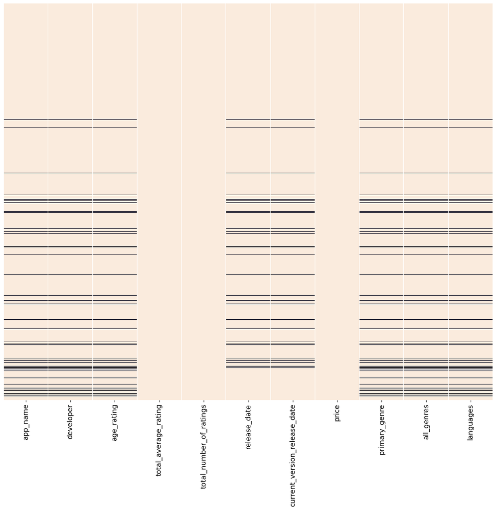

```python
# Mostramos el mapa de calor para nuestro DataFrame
matriz_nulos(apple)
```

El color beige representa los datos no-nulos, mientras que el color negro representa los valores nulos.

Este DataFrame en concreto está bastante limpio, ya que no es común encontrar una densidad de valores nulos tan pequeña.

Tendremos que analizar más en profundidad la calidad de los datos, ya que la ausencia de valores nulos no garantiza que la calidad de los datos sea óptima, ni que vaya a ser más sencillo el análisis de dichos datos. Dependiendo de qué variables estemos analizando, un valor numérico puede ser lo mismo que un valor nulo, o un string sin sentido. En estos casos, el análisis sería más tedioso que simplemente con valores nulos, ya que si es nulo, sabemos de antemano que ese dato es faltante.

Estudiaremos esto en más profundidad a medida que vayamos avanzando en el proceso de Data Cleaning.

### 2.3.2. Valores nulos - Correlación de valores nulos

En este caso, como hemos comentado, no tenemos una cantidad de valores nulos tan significativa que nos obligue a estudiar en profundidad los mismos y sus causas. Además, si observamos la matriz que acabamos de mostrar, podemos pensar que los valores nulos existentes en nuestro DataFrame son causa de falta de valores en Apps concretas, y no causa de una tercera variable que influya en dicho valor.

Sin embargo, si queremos realizar un análisis de la máxima calidad, es una buena praxis analizar las correlaciones existentes (si las hay) entre valores nulos, por lo que lo haremos de todas maneras. Además, esta función nos podría servir para análisis posteriores, o bien cuando analicemos el dataset de Google, o bien —si al final decidimos hacerlo— cuando analicemos el dataset resultante de combinar este dataset con el de Google (cuando ambos estén limpios).

Normalmente, hay datasets que contienen valores nulos que son causa de una tercera variable. Por ejemplo, imaginemos un dataset que contiene datos meteorológicos. Una de las columnas podría contener datos sobre la cantidad de lluvia acumulada; sin embargo, si un día no llueve, dicha columna no tendrá datos, y aparecerán valores nulos. En este caso, si estudiásemos la correlación existente entre variables para generar valores nulos, muy probablemente obtendríamos una fuerte correlación entre la variable 'LLUVIA' y la variable 'CANTIDAD DE LLUVIA'.

En este dataset (como ya hemos comentado), al estar confeccionado mediante Web Scraping, las causas no tienen por qué estar relacionadas entre sí, pero igualmente vamos a mostrar un mapa de calor con las correlaciones existentes entre valores nulos.

Para ello, vamos a crear una función que genere dicho mapa:

```python
def correlacion_nulos(df):
    """Crea una matriz de correlación para las
    columnas de un DataFrame con al menos un valor nulo.

    Params:
        df: Pandas DataFrame

    Returns:
        Evitamos hacer return para mostrar una visualización más limpia.
        Solo muestra el mapa de calor resultante.
    """
    cols_valores_nulos = df.columns[df.isnull().sum() > 0]
    corr_nulos = df[cols_valores_nulos].isnull().corr()

    # Máscara para evitar valores repetidos y facilitar la visualización
    corr_nulos = corr_nulos.iloc[1:, :-1]
    mascara = np.triu(np.ones_like(corr_nulos), k=1)

    # Mapa de calor de los valores
    plt.figure(figsize=(20, 14))
    ax = sns.heatmap(corr_nulos, vmin=-1, vmax=1, cbar=False,
                    cmap='RdBu', mask=mascara, annot=True)

    # Formateamos el texto del gráfico para facilitar la visualización
    for text in ax.texts:
        t = float(text.get_text())
        if -0.05 < t < 0.01:
            text.set:text('')
        else:
            text.set_text(round(t, 2))
        text.set_fontsize('x-large')
    plt.xticks(rotation=90, size='x-large')
    plt.yticks(rotation=0, size='x-large')

    plt.show()
```

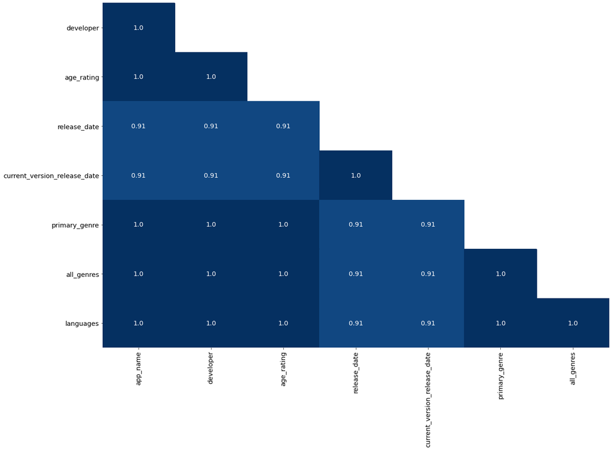

```python
# Llamamos a la función con nuestro DataFrame
correlacion_nulos(apple)
```

Efectivamente, vemos como las correlaciones son muy fuertes, y esto es debido a que cuando falta un dato, faltan todos los demás. Esto se debe a que existen Apps que en el momento en el que se confeccionó el dataset no tenían prácticamente datos disponibles, o que en algún momento de la estructuración de los datos se perdieron los de algunas Apps concretas por algún motivo que desconocemos.

### 2.3.3. Valores nulos - Criterio para la eliminación de filas

Para poder realizar el análisis que queremos, necesitamos al menos algunos datos para cada App.

En este caso, necesitamos conocer, al menos:

- El género de la App
- El precio de la App
- Los idiomas disponibles de la App
- Las valoraciones de la App

Si atendemos de nuevo a la matriz de valores nulos, vemos que cuando existen valores nulos en una App, tres de ellos siempre son el **género**, las **etiquetas de género (subcategorías)** y los **lenguajes**. Estos datos son vitales para nuestro estudio, porque queremos conocer precisamente las categorías donde mejor podría encajar nuestra App, y compararla con otras Apps cuyos lenguajes disponibles sean los mismos que los nuestros.

En este punto no eliminaremos ninguna fila, ya que aún no hemos establecido criterios generales que sí que nos obligarán a eliminar muchas de ellas. Por ejemplo, dado que solamente queremos Apps que sean gratuitas, eliminaremos todas aquellas que no lo sean (no existen valores nulos en la columna `price`); como no queremos lanzar al mercado asiático nuestra App (por el idioma), o mejor dicho, no queremos competir contra Apps cuyo lenguaje sea distinto de castellano o inglés, eliminaremos todas las Apps que tengan nombres asiáticos o cuyo lenguaje disponible sea distinto del castellano o el inglés. Una vez hagamos estas operaciones, confiamos en que muchas de estas columnas que de momento vamos a mantener hayan sido eliminadas de forma natural.

De todas maneras, llegado el momento volveremos a evaluar la posibilidad de eliminarlas manualmente, si la situación lo requiere.

### 2.3.4. Valores nulos - Filtrando Apps Gratuitas

Ya que nuestro propósito es lanzar una App gratutita al mercado, no tendría sentido estudiar el mercado de las Apps de pago.

Si queremos lanzar un producto al mercado, tendremos que analizar el 'sub-mercado' que se forma con los productos que compiten entre sí. Por ejemplo, si queremos montar una empresa de ropa, y nuestras prendas serán de bajo coste, no tendría sentido compararnos con marcas de alta costura como Gucci, D&G, Carolina Herrera... Pese a que nosotros —al igual que ellos— vendemos productos textiles, no es nuestra intención llegar a los clientes de estas firmas. Sin embargo, sí tendría sentido comparar nuestros productos con los de Primark, Alcampo o Pull&Bear, porque son marcas que ofrecen moda a bajo coste: este sí sería el mercado al que nos queremos incorporar y el cliente de estas marcas sería nuestro potencial cliente.

En el caso que nos ocupa, y como nuestra App será gratuita, eliminaremos todas aquellas Apps presentes en nuestro dataset que sean de pago. Lo mismo haremos con los demás criterios que establecimos al inicio del proyecto, pero lo haremos paso a paso.

Vamos a estudiar la columna que representa el precio de las Apps en el dataset; en este caso la columna es `price`

```python
# No tenemos valores nulos en la columna 'price'
apple['price'].isnull().sum()
```

```
0
```

```python
# Distribución de valores en la columna 'price'
apple['price'].value_counts()
```

```
 0.00      649376
-1.00       39192
 0.99       27561
 1.99       15571
 2.99       10291
            ...
 209.99         2
 43.99          1
 899.99         1
 599.99         1
 239.99         1
Name: price, Length: 88, dtype: int64
```

Vemos que tenemos valores extraños en esta columna. Sin haberla explorado en profundidad, observamos que por lo pronto existen 39,192 Apps que tienen un precio negativo, concretamente de \$-1.00.

Antes de nada, y aunque visualmente no va a ser lo más atractivo, vamos a mostrar el output completo de la tabla de frecuencias, para comprobar si existisen más valores extraños aparte de los que hemos comentado:

```python
# Con esta línea obligamos a mostrar un máximo de 100 filas
pd.options.display.max_rows = 100

apple['price'].value_counts().sort_index()
```

```
-1.00       39192
 0.00      649376
 0.99       27561
 1.99       15571
 2.99       10291
 3.99        5077
 4.99        5206
 5.99        1340
 6.99        1479
 7.99         915
 8.99         563
 9.99        2260
 10.99        185
 11.99        272
 12.99        230
 13.99        177
 14.99        504
 15.99        119
 16.99        101
 17.99        144
 18.99         55
 19.99        923
 20.99        164
 21.99         99
 22.99         61
 23.99         39
 24.99        257
 25.99         35
 26.99         53
 27.99         23
 28.99         24
 29.99        254
 30.99         15
 31.99         29
 32.99         11
 33.99         18
 34.99         59
 35.99         41
 36.99         11
 37.99          5
```

[output cut: 34 more lines]

```
 209.99         2
 219.99         4
 229.99         4
 239.99         1
 249.99        14
 299.99        19
 349.99        17
 399.99        13
 449.99         3
 499.99         3
 599.99         1
 699.99         4
 899.99         1
 999.99        15
Name: price, dtype: int64
```

```python
# Creamos un nuevo dataset de Apps con precio negativo
negative_price = apple[apple.price < 0]
negative_price = negative_price.reset_index()
negative_price
```

|  | index | app_name | developer | age_rating | total_average_rating | total_number_of_ratings | release_date | current_version_release_date | price | primary_genre | all_genres | languages |
| --- | --- | --- | --- | --- | --- | --- | --- | --- | --- | --- | --- | --- |
| 0 | 79 | NaN | NaN | NaN | -1.0 | -1.0 | NaN | NaN | -1.0 | NaN | NaN | NaN |
| 1 | 215 | NaN | NaN | NaN | -1.0 | -1.0 | NaN | NaN | -1.0 | NaN | NaN | NaN |
| 2 | 443 | NaN | NaN | NaN | -1.0 | -1.0 | NaN | NaN | -1.0 | NaN | NaN | NaN |
| 3 | 671 | NaN | NaN | NaN | -1.0 | -1.0 | NaN | NaN | -1.0 | NaN | NaN | NaN |
| 4 | 1039 | NaN | NaN | NaN | -1.0 | -1.0 | NaN | NaN | -1.0 | NaN | NaN | NaN |
| ... | ... | ... | ... | ... | ... | ... | ... | ... | ... | ... | ... | ... |
| 39187 | 763783 | NaN | NaN | NaN | -1.0 | -1.0 | 0000-00-00T00:00:00Z | 0000-00-00T00:00:00Z | -1.0 | NaN | NaN | NaN |
| 39188 | 763792 | NaN | NaN | NaN | -1.0 | -1.0 | 0000-00-00T00:00:00Z | 0000-00-00T00:00:00Z | -1.0 | NaN | NaN | NaN |
| 39189 | 763814 | NaN | NaN | NaN | -1.0 | -1.0 | 0000-00-00T00:00:00Z | 0000-00-00T00:00:00Z | -1.0 | NaN | NaN | NaN |
| 39190 | 763819 | NaN | NaN | NaN | -1.0 | -1.0 | 0000-00-00T00:00:00Z | 0000-00-00T00:00:00Z | -1.0 | NaN | NaN | NaN |
| 39191 | 763822 | NaN | NaN | NaN | -1.0 | -1.0 | 0000-00-00T00:00:00Z | 0000-00-00T00:00:00Z | -1.0 | NaN | NaN | NaN |

39192 rows × 12 columns

Casualmente, el número de filas de este dataset que acabamos de construir es muy similar al número de valores nulos que encontramos cuando estuvimos analizando los valores nulos.

Vamos a explorar detalladamente los valores nulos de este nuevo DataFrame:

```python
negative_price.info()
```

```
<class 'pandas.core.frame.DataFrame'>
RangeIndex: 39192 entries, 0 to 39191
Data columns (total 12 columns):
 #   Column                        Non-Null Count  Dtype
---  ------                        --------------  -----
 0   index                         39192 non-null  int64
 1   app_name                      113 non-null    object
 2   developer                     113 non-null    object
 3   age_rating                    113 non-null    object
 4   total_average_rating          39192 non-null  float64
 5   total_number_of_ratings       39192 non-null  float64
 6   release_date                  6508 non-null   object
 7   current_version_release_date  6508 non-null   object
 8   price                         39192 non-null  float64
 9   primary_genre                 113 non-null    object
 10  all_genres                    113 non-null    object
 11  languages                     113 non-null    object
dtypes: float64(3), int64(1), object(8)
memory usage: 3.6+ MB
```

Efectivamente, vemos como existen solamente 113 valores no-nulos en esas mismas seis columnas que nombramos en la distribución de valores nulos.

Como comentamos anteriormente, no podemos extraer conclusiones que nos sirvan para nuestros propósitos si no tenemos información sobre el género de la App o los lenguajes, y precisamente son estos datos los que nos faltan.

Por tanto, ahora sí, vamos a eliminar todas las filas de este dataset que tengan valores nulos en estas columnas, para analizar las Apps restantes, que solo serán 113.

```python
# Mantenemos solamente las filas que no contengan valores nulos en la columna 'all_genres'
negative_price = negative_price[negative_price['all_genres'].notna()]
negative_price = negative_price.reset_index()
negative_price
```

|  | level_0 | index | app_name | developer | age_rating | total_average_rating | total_number_of_ratings | release_date | current_version_release_date | price | primary_genre | all_genres | languages |
| --- | --- | --- | --- | --- | --- | --- | --- | --- | --- | --- | --- | --- | --- |
| 0 | 6 | 1388 | All Daf | Orthodox Union | 4+ | -1.0 | -1.0 | 2019-12-14T08:00:00Z | 2019-12-14T08:00:00Z | -1.0 | Book | ['Books'] | ['EN'] |
| 1 | 57 | 20481 | Snowman Story | Daigo Sato | 4+ | -1.0 | -1.0 | 2019-12-14T08:00:00Z | 2019-12-14T08:00:00Z | -1.0 | Games | ['Games', 'Books', 'Puzzle', 'Adventure'] | ['EN', 'JA', 'KO'] |
| 2 | 268 | 64509 | Cloud - Self-hosted storage | Adam Kopec | 4+ | -1.0 | -1.0 | 2019-12-20T08:00:00Z | 2019-12-20T08:00:00Z | -1.0 | Productivity | ['Productivity', 'Business'] | ['EN'] |
| 3 | 739 | 122904 | Loom - Quick Videos | Loom, Inc | 4+ | -1.0 | -1.0 | 2019-12-03T08:00:00Z | 2019-12-03T08:00:00Z | -1.0 | Business | ['Business', 'Photo & Video'] | ['EN'] |
| 4 | 1175 | 166894 | Scanner App ⊙ | Imane El Houty | 4+ | -1.0 | -1.0 | 2020-01-01T08:00:00Z | 2020-01-01T08:00:00Z | -1.0 | Business | ['Business', 'Utilities'] | ['EN'] |
| ... | ... | ... | ... | ... | ... | ... | ... | ... | ... | ... | ... | ... | ... |
| 108 | 38814 | 760312 | Takeshi and Hiroshi | Oink Games Inc. | 12+ | 4.5 | 125.0 | 2019-11-08T08:00:00Z | 2020-01-13T17:53:23Z | -1.0 | Games | ['Games', 'Adventure', 'Family'] | ['EN', 'JA'] |
| 109 | 38818 | 760334 | Tales of Memo | TENDAYS STUDIO PTE. LTD. | 9+ | 3.0 | 44.0 | 2019-10-25T07:00:00Z | 2019-12-11T02:06:21Z | -1.0 | Games | ['Games', 'Puzzle'] | ['AR', 'ZH', 'DA', 'NL', 'EN', 'FI', 'FR', 'DE... |
| 110 | 38825 | 760427 | Tangle Tower | SFB Games | 9+ | 5.0 | 1105.0 | 2019-09-19T07:00:00Z | 2019-12-19T23:25:00Z | -1.0 | Games | ['Games', 'Adventure'] | ['AR', 'ZH', 'NL', 'EN', 'FR', 'DE', 'IT', 'JA... |
| 111 | 38991 | 762012 | Things That Go Bump | Tinybop Inc. | 4+ | 4.0 | 66.0 | 2019-10-18T07:00:00Z | 2020-02-12T23:08:36Z | -1.0 | Games | ['Games', 'Action', 'Family'] | ['EN'] |
| 112 | 39176 | 763676 | Towaga: Among Shadows | Noodlecake | 12+ | 4.5 | 80.0 | 2019-09-19T07:00:00Z | 2020-02-14T14:12:28Z | -1.0 | Games | ['Games', 'Action'] | ['EN'] |

113 rows × 13 columns

Ahora mismo solo tenemos 113 Apps con un precio negativo. Vamos a comprobar manualmente si estas Apps son gratuitas o son de pago. Evidentemente, no vamos a comprobar las 113 Apps a mano; lo que haremos será tomar una muestra de 10 Apps, y si 8/10 son gratuitas, asumiremos que todas lo son.

```python
# Tomamos una muestra del DataFrame
negative_price.sample(10)
```

|  | level_0 | index | app_name | developer | age_rating | total_average_rating | total_number_of_ratings | release_date | current_version_release_date | price | primary_genre | all_genres | languages |
| --- | --- | --- | --- | --- | --- | --- | --- | --- | --- | --- | --- | --- | --- |
| 79 | 36050 | 735591 | Painty Mob | Devolver | 4+ | 3.5 | 3.5 | 2019-09-19T07:00:00Z | 2019-10-06T23:00:41Z | -1.0 | Games | ['Games', 'Casual'] | ['EN'] |
| 82 | 36573 | 740303 | Possessions. | Noodlecake | 9+ | 4.0 | 229.0 | 2019-09-19T07:00:00Z | 2019-10-21T17:53:54Z | -1.0 | Games | ['Games', 'Casual', 'Puzzle'] | ['AR', 'NL', 'EN', 'FR', 'DE', 'IT', 'JA', 'KO... |
| 41 | 32281 | 696616 | Discolored | Shifty Eye | 9+ | 4.0 | 282.0 | 2019-11-08T08:00:00Z | 2019-12-20T21:31:41Z | -1.0 | Games | ['Games', 'Adventure'] | ['AR', 'NL', 'EN', 'FR', 'DE', 'IT', 'JA', 'KO... |
| 110 | 38825 | 760427 | Tangle Tower | SFB Games | 9+ | 5.0 | 1105.0 | 2019-09-19T07:00:00Z | 2019-12-19T23:25:00Z | -1.0 | Games | ['Games', 'Adventure'] | ['AR', 'ZH', 'NL', 'EN', 'FR', 'DE', 'IT', 'JA... |
| 112 | 39176 | 763676 | Towaga: Among Shadows | Noodlecake | 12+ | 4.5 | 80.0 | 2019-09-19T07:00:00Z | 2020-02-14T14:12:28Z | -1.0 | Games | ['Games', 'Action'] | ['EN'] |
| 23 | 19989 | 541625 | SuperBall Shooter Blast | Le Phuong Thuy | 4+ | -1.0 | -1.0 | 2020-02-18T08:00:00Z | 2020-02-18T08:00:00Z | -1.0 | Games | ['Games', 'Casual', 'Entertainment', 'Family'] | ['ZH', 'EN', 'JA'] |
| 58 | 34463 | 718984 | Jenny LeClue - Detectivu | Mografi | 12+ | 4.0 | 445.0 | 2019-09-19T07:00:00Z | 2019-11-08T02:17:32Z | -1.0 | Games | ['Games', 'Adventure'] | ['AR', 'NL', 'EN', 'FR', 'DE', 'IT', 'JA', 'KO... |
| 72 | 35804 | 732913 | NIGHTMARE FARM | Hit-Point Co., Ltd. | 9+ | 3.0 | 53.0 | 2019-10-05T07:00:00Z | 2020-01-28T18:44:46Z | -1.0 | Games | ['Games', 'Simulation'] | ['AR', 'NL', 'EN', 'FR', 'DE', 'IT', 'JA', 'KO... |
| 53 | 34016 | 714256 | Hexaflip: The Action Puzzler | Rogue Games | 4+ | 4.0 | 205.0 | 2019-09-19T07:00:00Z | 2020-01-17T14:25:47Z | -1.0 | Games | ['Games', 'Casual'] | ['AR', 'ZH', 'NL', 'EN', 'FR', 'DE', 'IT', 'JA... |
| 7 | 1835 | 224820 | Aviation Exam: FAA, EASA, ATPL | Ahmet Serdar Karadeniz | 4+ | -1.0 | -1.0 | 2020-01-01T08:00:00Z | 2020-01-01T08:00:00Z | -1.0 | Education | ['Education'] | ['EN'] |

Al haber comprobado manualmente las cuatro primeras Apps, tres de ellas son de pago, por lo que directamente asumiremos que estas 113 Apps son de pago. Somos conscientes de que perderemos una parte de los datos, pero la proporción es tan pequeña que la asumiremos en favor del tiempo que nos ahorraremos.

Por tanto, ya podemos eliminar del dataset principal *apple* todas las Apps cuyo valor sea distinto de 0.00

```python
# Creamos el DataFrame de Apps gratuitas 'apple_free', y mostramos los valores nulos
apple_free = apple[apple.price == 0.00]
apple_free.info()
```

```
<class 'pandas.core.frame.DataFrame'>
Int64Index: 649376 entries, 0 to 763830
Data columns (total 11 columns):
 #   Column                        Non-Null Count   Dtype
---  ------                        --------------   -----
 0   app_name                      649376 non-null  object
 1   developer                     649376 non-null  object
 2   age_rating                    649376 non-null  object
 3   total_average_rating          649376 non-null  float64
 4   total_number_of_ratings       649376 non-null  float64
 5   release_date                  649376 non-null  object
 6   current_version_release_date  649376 non-null  object
 7   price                         649376 non-null  float64
 8   primary_genre                 649376 non-null  object
 9   all_genres                    649376 non-null  object
 10  languages                     649376 non-null  object
dtypes: float64(3), object(8)
memory usage: 59.5+ MB
```

Cuando establecimos el Criterio para eliminación de filas (2.3.3), esperábamos que durante el proceso de Data Cleaning muchas de las filas que tuvieran valores nulos fueran desapareciendo de manera natural.

En este caso, al eliminar todas las Apps que no fuesen gratuitas, han desaparecido por completo, lo que no es nada común. Esto nos evitará tener que lidiar con valores nulos a partir de ahora, aunque sí tendremos que seguir realizando las demás tareas típicas de Data Cleaning.

## 2.4. Lenguajes - filtrado

Como los idiomas disponibles en nuestra App serán el castellano y el inglés, vamos a eliminar de nuestro DataFrame todas las Apps que no estén disponibles en alguno de estos idiomas.

Primeramente, tenemos que localizar de qué manera están representados estos dos idiomas en el DataFrame.

Vamos a ver la tabla de frecuencias de la columna `languages` :

```python
# Valores distintos para la columna 'languages'
apple_free.languages.value_counts()
```

```
['EN']                                                                                                                449389
[]                                                                                                                     11872
['EN', 'ZH']                                                                                                            7709
['EN', 'ES']                                                                                                            7448
['EN', 'DE']                                                                                                            6481
                                                                                                                       ...
['AR', 'EN', 'PT', 'RU', 'ZH']                                                                                             1
['AR', 'DA', 'NL', 'EN', 'FI', 'FR', 'DE', 'IT', 'JA', 'KO', 'NB', 'PT', 'RU', 'ZH', 'ES', 'SV', 'TH', 'ZH', 'VI']         1
['ZH', 'NL', 'EN', 'FR', 'DE', 'IT', 'JA', 'PL', 'PT', 'ES', 'ZH']                                                         1
['EN', 'IT', 'JA', 'RU']                                                                                                   1
['CS', 'NL', 'EN', 'FR', 'LV', 'ZH', 'SV', 'TH', 'ZH']                                                                     1
Name: languages, Length: 11417, dtype: int64
```

Tenemos 11,417 valores distintos en la Serie que acabamos de obtener, por lo que vamos a hacer un filtrado exhaustivo.

Obtendremos un DataFrame en el que solamente aparezcan Apps donde los strings **'EN'** ó **'ES'** estén presentes en la columna `languages` :

```python
apple_free_es_en = apple_free[(apple_free.languages.str.contains('EN')) | (apple_free.languages.str.contains('ES'))]
apple_free_es_en
```

|  | app_name | developer | age_rating | total_average_rating | total_number_of_ratings | release_date | current_version_release_date | price | primary_genre | all_genres | languages |
| --- | --- | --- | --- | --- | --- | --- | --- | --- | --- | --- | --- |
| 0 | abc - writing style cursive flashcards worksheets | Wattana Kamdee | 4+ | -1.0 | -1.0 | 2017-04-10T23:00:59Z | 2017-04-10T23:00:59Z | 0.0 | Games | ['Games', 'Books', 'Family'] | ['EN'] |
| 2 | abcForAll tw | CHEN-HUNG LEE | 4+ | -1.0 | -1.0 | 2017-02-09T03:50:59Z | 2019-05-30T07:22:55Z | 0.0 | Education | ['Education', 'Books'] | ['EN'] |
| 3 | abegs books reader | Arab Bureau of Education for the Gulf States | 4+ | -1.0 | -1.0 | 2017-11-21T02:06:58Z | 2017-11-21T02:06:58Z | 0.0 | Education | ['Education', 'Books'] | ['EN'] |
| 4 | aBooks - Sách Truyện Online | Phuong Anh Do | 12+ | 4.5 | 202.0 | 2016-09-07T06:33:45Z | 2018-01-17T21:10:42Z | 0.0 | Book | ['Books', 'Lifestyle'] | ['EN', 'VI'] |
| 5 | aComic Manga Comic Novel Story | Mong Anh Nguyen | 9+ | -1.0 | -1.0 | 2019-06-30T09:21:38Z | 2019-07-23T08:38:25Z | 0.0 | Entertainment | ['Entertainment', 'Books'] | ['EN'] |
| ... | ... | ... | ... | ... | ... | ... | ... | ... | ... | ... | ... |
| 763826 | Towers: Balance Building | Zexian Chen | 4+ | 4.5 | 28.0 | 2015-08-25T11:51:20Z | 2016-06-06T17:09:32Z | 0.0 | Games | ['Games', 'Casual', 'Family'] | ['EN'] |
| 763827 | Towerstomp | A To Play Ltd. | 4+ | -1.0 | -1.0 | 2018-04-06T15:19:37Z | 2018-05-23T14:31:53Z | 0.0 | Games | ['Games', 'Action', 'Casual'] | ['EN'] |
| 763828 | Towervale | PC Studio, Inc | 4+ | 4.5 | 21.0 | 2018-12-28T20:53:08Z | 2018-12-28T20:53:08Z | 0.0 | Games | ['Games', 'Adventure', 'Action'] | ['EN'] |
| 763829 | Town Bird - Flap Flap Bird | Abdusodiq Saidov | 4+ | -1.0 | -1.0 | 2014-02-27T21:08:18Z | 2014-07-14T16:55:43Z | 0.0 | Games | ['Games', 'Family', 'Adventure', 'Lifestyle'] | ['EN'] |
| 763830 | Town Center car parking | DO THI THUY | 4+ | -1.0 | -1.0 | 2017-06-20T23:01:00Z | 2017-06-20T23:01:00Z | 0.0 | Games | ['Games', 'Simulation'] | ['EN'] |

618978 rows × 11 columns

Tenemos 618,978 Apps que al menos están disponibles en inglés o en castellano.

En principio es lo que buscamos, no obstante vamos a comprobar cuantas Apps están disponibles en ambos idiomas:

```python
# Número de Apps cuyos lenguajes disponibles incluyen el castellano y el inglés
apple_free_es_and_en = apple_free[(apple_free.languages.str.contains('EN')) & (apple_free.languages.str.contains('ES'))]
apple_free_es_and_en
```

|  | app_name | developer | age_rating | total_average_rating | total_number_of_ratings | release_date | current_version_release_date | price | primary_genre | all_genres | languages |
| --- | --- | --- | --- | --- | --- | --- | --- | --- | --- | --- | --- |
| 26 | andisk学习盘 | Hui Han | 17+ | -1.0 | -1.0 | 2019-06-28T19:40:55Z | 2019-10-23T15:27:09Z | 0.0 | Education | ['Education', 'Books'] | ['EN', 'FR', 'DE', 'ZH', 'ES'] |
| 34 | aThingBook | com.thai-g.com | 4+ | 4.5 | 6.0 | 2011-09-08T00:00:25Z | 2016-08-19T19:56:30Z | 0.0 | Book | ['Books', 'Lifestyle'] | ['AR', 'CA', 'CS', 'DA', 'NL', 'EN', 'FI', 'FR... |
| 40 | bega-elbe2 | Odilo | 4+ | -1.0 | -1.0 | 2018-02-14T16:56:02Z | 2019-10-29T05:49:39Z | 0.0 | Book | ['Books', 'Utilities'] | ['EU', 'CA', 'NL', 'EN', 'FR', 'GL', 'DE', 'PT... |
| 61 | booksecrets - Discover secrets for your books | booksecrets p.c. | 4+ | -1.0 | -1.0 | 2015-09-24T06:48:35Z | 2016-11-17T17:37:12Z | 0.0 | Book | ['Books', 'Entertainment'] | ['EN', 'IT', 'KO', 'PT', 'ES', 'ZH'] |
| 72 | c,c++ debugging programs | Mala M | 4+ | -1.0 | -1.0 | 2016-09-05T23:24:03Z | 2016-09-05T23:24:03Z | 0.0 | Education | ['Education', 'Books'] | ['DA', 'EN', 'PT', 'RU', 'ES', 'SV', 'UK'] |
| ... | ... | ... | ... | ... | ... | ... | ... | ... | ... | ... | ... |
| 763780 | Tower Power - Kawaii Shooter | LemonChili Games | 4+ | 1.5 | 317.0 | 2018-10-20T07:00:00Z | 2019-12-03T16:24:31Z | 0.0 | Games | ['Games', 'Casual', 'Action'] | ['EN', 'PT', 'ES'] |
| 763789 | Tower Sandwich Free - Food Maker Game | Amr EL-Rafie | 4+ | -1.0 | -1.0 | 2014-01-11T02:13:11Z | 2014-02-07T05:21:01Z | 0.0 | Games | ['Games', 'Simulation', 'Puzzle'] | ['CA', 'CS', 'DA', 'NL', 'EN', 'FI', 'FR', 'DE... |
| 763799 | Tower Stack - Skyrise | Motto23 Games | 4+ | -1.0 | -1.0 | 2018-07-28T04:26:13Z | 2018-07-28T04:26:13Z | 0.0 | Games | ['Games', 'Casual', 'Puzzle'] | ['EN', 'FR', 'DE', 'IT', 'JA', 'KO', 'PT', 'RU... |
| 763800 | Tower Stack Building Blocks | Makeover Mania Story Games | 4+ | -1.0 | -1.0 | 2015-03-01T08:00:00Z | 2015-10-31T21:53:24Z | 0.0 | Games | ['Games', 'Strategy', 'Simulation'] | ['AR', 'CA', 'CS', 'DA', 'NL', 'EN', 'FI', 'FR... |
| 763807 | Tower Tycoon - Idle Simulator | Adrian Zarzycki | 4+ | 4.5 | 2786.0 | 2018-05-16T07:00:00Z | 2019-10-30T11:05:09Z | 0.0 | Games | ['Games', 'Simulation', 'Strategy'] | ['ZH', 'EN', 'FR', 'DE', 'IT', 'PL', 'RU', 'ES'] |

89581 rows × 11 columns

En este caso tenemos 89,581 Apps que incluyen ambas opciones (castellano e inglés).

Si hubiese habido más, quizás podríamos habernos planteado el seguir analizando este último DataFrame, pero la diferencia es demasiado grande entre el DataFrame *apple_free_es_en* y este último, concretamente más de medio millón de Apps.

Además, teniendo en cuenta que el idioma es solamente una opción —el usuario solamente elegirá el que más le convenga— en principio la App tendría el mismo impacto en un usuario cuyo idioma nativo sea el inglés como en un usuario cuyo idioma nativo sea el castellano.

Por tanto, seguiremos estudiando el DataFrame *apple_free_es_en*, que tiene 618,978 Apps, y todas ellas están disponibles, al menos, en inglés o castellano.

Podríamos haber profundizado más en el idioma de la App, pero hemos obtenido 618,978 resultados de 649,376 (más del 95%). Esto significa que, aun descartando unas 30,000 Apps, tenemos aún margen de maniobra para profundizar más adelante si necesitásemos encontrar Apps que estén traducidas en algún otro idioma adicional.

Vamos a ver los valores que tenemos ahora en el DataFrame, correspondientes a la columna `languages` :

```python
# Reseteamos los índices por comodidad
apple_free_es_en = apple_free_es_en.reset_index()
apple_free_es_en.languages.value_counts()
```

```
['EN']                                                                                                                449389
['EN', 'ZH']                                                                                                            7709
['EN', 'ES']                                                                                                            7448
['EN', 'DE']                                                                                                            6481
['EN', 'JA']                                                                                                            6470
                                                                                                                       ...
['EN', 'IT', 'JA', 'RU']                                                                                                   1
['EN', 'HE', 'JA', 'PL', 'PT', 'RU', 'ZH', 'ES']                                                                           1
['EN', 'IT', 'PT', 'ZH', 'ES']                                                                                             1
['AR', 'ZH', 'EN', 'FR', 'JA', 'KO', 'PT', 'RU', 'ZH', 'ES']                                                               1
['AR', 'DA', 'NL', 'EN', 'FR', 'DE', 'EL', 'IT', 'JA', 'KO', 'MS', 'PT', 'RU', 'ZH', 'ES', 'TH', 'ZH', 'TR', 'VI']         1
Name: languages, Length: 11237, dtype: int64
```

Vemos que el valor más repetido es 'EN', que es el valor correspondiente al inglés, con 449,389 Apps. Esto representa alrededor del 72% del total de Apps disponibles en nuestro dataset.

https://omegat.sourceforge.io/manual-standard/es/appendix.languages.html

Asumiremos que las Apps que estén traducidas a idiomas asiáticos no nos interesan, por los dos siguientes motivos:

- 1. Si una App está traducida a múltiples idiomas, lo más probable es que el desarrollador de la App sea una empresa contra la que no buscamos competir.
- 1. Si no está traducida a una gran cantidad de idiomas, pero uno o varios de ellos son idiomas asiáticos, es que la App está dirigida a un usuario oriental, por lo que podemos prescindir de ella.

Vamos a tratar de eliminar el mayor número de Apps posibles que tengan las siguientes combinaciones de idiomas:

- Inglés y chino
- Inglés y japonés
- Inglés e hindú
- Inglés y tailandés
- Inglés y koreano
- Inglés y urdu (idioma oficial de Pakistán) *Pakistán es uno de los países más poblados de Asia, con una población de 220 millones de habitantes.*

```python
# Creamos las máscaras booleanas
eng_zh = apple_free_es_en['languages'].str.contains('EN') & apple_free_es_en['languages'].str.contains('ZH') # inglés y chino
eng_ja = apple_free_es_en['languages'].str.contains('EN') & apple_free_es_en['languages'].str.contains('JA') # inglés y japonés
eng_hi = apple_free_es_en['languages'].str.contains('EN') & apple_free_es_en['languages'].str.contains('HI') # inglés e hindi
eng_th = apple_free_es_en['languages'].str.contains('EN') & apple_free_es_en['languages'].str.contains('TH') # inglés y tailandés
eng_ko = apple_free_es_en['languages'].str.contains('EN') & apple_free_es_en['languages'].str.contains('KO') # inglés y koreano
eng_ur = apple_free_es_en['languages'].str.contains('EN') & apple_free_es_en['languages'].str.contains('UR') # inglés y urdu
```

```python
# Creamos un nuevo DataFrame a partir de las máscaras booleanas,
# cuyos índices nos servirán para eliminarlos en el original
apple_orient = apple_free_es_en[(eng_zh) | (eng_ja) | (eng_hi) | (eng_th) | (eng_ko) | (eng_ur)]
apple_orient
```

|  | index | app_name | developer | age_rating | total_average_rating | total_number_of_ratings | release_date | current_version_release_date | price | primary_genre | all_genres | languages |
| --- | --- | --- | --- | --- | --- | --- | --- | --- | --- | --- | --- | --- |
| 9 | 11 | ahead "アヘッド” | Intelade Inc. | 4+ | -1.0 | -1.0 | 2014-01-31T08:00:00Z | 2016-02-12T07:38:39Z | 0.0 | Book | ['Books', 'Magazines & Newspapers'] | ['EN', 'JA'] |
| 19 | 25 | anan magazine | マガジンハウス | 4+ | -1.0 | -1.0 | 2015-06-27T12:32:38Z | 2018-03-22T15:42:34Z | 0.0 | Book | ['Books', 'Magazines & Newspapers'] | ['EN', 'JA'] |
| 20 | 26 | andisk学习盘 | Hui Han | 17+ | -1.0 | -1.0 | 2019-06-28T19:40:55Z | 2019-10-23T15:27:09Z | 0.0 | Education | ['Education', 'Books'] | ['EN', 'FR', 'DE', 'ZH', 'ES'] |
| 23 | 29 | app开发中的神兵利器 | Li Fazhan | 4+ | -1.0 | -1.0 | 2017-03-09T15:25:54Z | 2019-05-06T02:51:10Z | 0.0 | Education | ['Education', 'Books'] | ['EN', 'ZH'] |
| 27 | 34 | aThingBook | com.thai-g.com | 4+ | 4.5 | 6.0 | 2011-09-08T00:00:25Z | 2016-08-19T19:56:30Z | 0.0 | Book | ['Books', 'Lifestyle'] | ['AR', 'CA', 'CS', 'DA', 'NL', 'EN', 'FI', 'FR... |
| ... | ... | ... | ... | ... | ... | ... | ... | ... | ... | ... | ... | ... |
| 618928 | 763770 | Tower of Infinity | DAERI SOFT | 9+ | -1.0 | -1.0 | 2018-06-01T03:58:24Z | 2019-01-03T13:51:28Z | 0.0 | Games | ['Games', 'Action', 'Role Playing'] | ['EN', 'JA', 'KO', 'ZH', 'ZH', 'TR'] |
| 618942 | 763789 | Tower Sandwich Free - Food Maker Game | Amr EL-Rafie | 4+ | -1.0 | -1.0 | 2014-01-11T02:13:11Z | 2014-02-07T05:21:01Z | 0.0 | Games | ['Games', 'Simulation', 'Puzzle'] | ['CA', 'CS', 'DA', 'NL', 'EN', 'FI', 'FR', 'DE... |
| 618951 | 763799 | Tower Stack - Skyrise | Motto23 Games | 4+ | -1.0 | -1.0 | 2018-07-28T04:26:13Z | 2018-07-28T04:26:13Z | 0.0 | Games | ['Games', 'Casual', 'Puzzle'] | ['EN', 'FR', 'DE', 'IT', 'JA', 'KO', 'PT', 'RU... |
| 618952 | 763800 | Tower Stack Building Blocks | Makeover Mania Story Games | 4+ | -1.0 | -1.0 | 2015-03-01T08:00:00Z | 2015-10-31T21:53:24Z | 0.0 | Games | ['Games', 'Strategy', 'Simulation'] | ['AR', 'CA', 'CS', 'DA', 'NL', 'EN', 'FI', 'FR... |
| 618959 | 763807 | Tower Tycoon - Idle Simulator | Adrian Zarzycki | 4+ | 4.5 | 2786.0 | 2018-05-16T07:00:00Z | 2019-10-30T11:05:09Z | 0.0 | Games | ['Games', 'Simulation', 'Strategy'] | ['ZH', 'EN', 'FR', 'DE', 'IT', 'PL', 'RU', 'ES'] |

94076 rows × 12 columns

```python
# Eliminamos los índices que no nos interesan y mostramos el DataFrame resultante
apple_free_es_en = apple_free_es_en.drop(apple_orient.index)
apple_free_es_en.head()
```

|  | index | app_name | developer | age_rating | total_average_rating | total_number_of_ratings | release_date | current_version_release_date | price | primary_genre | all_genres | languages |
| --- | --- | --- | --- | --- | --- | --- | --- | --- | --- | --- | --- | --- |
| 0 | 0 | abc - writing style cursive flashcards worksheets | Wattana Kamdee | 4+ | -1.0 | -1.0 | 2017-04-10T23:00:59Z | 2017-04-10T23:00:59Z | 0.0 | Games | ['Games', 'Books', 'Family'] | ['EN'] |
| 1 | 2 | abcForAll tw | CHEN-HUNG LEE | 4+ | -1.0 | -1.0 | 2017-02-09T03:50:59Z | 2019-05-30T07:22:55Z | 0.0 | Education | ['Education', 'Books'] | ['EN'] |
| 2 | 3 | abegs books reader | Arab Bureau of Education for the Gulf States | 4+ | -1.0 | -1.0 | 2017-11-21T02:06:58Z | 2017-11-21T02:06:58Z | 0.0 | Education | ['Education', 'Books'] | ['EN'] |
| 3 | 4 | aBooks - Sách Truyện Online | Phuong Anh Do | 12+ | 4.5 | 202.0 | 2016-09-07T06:33:45Z | 2018-01-17T21:10:42Z | 0.0 | Book | ['Books', 'Lifestyle'] | ['EN', 'VI'] |
| 4 | 5 | aComic Manga Comic Novel Story | Mong Anh Nguyen | 9+ | -1.0 | -1.0 | 2019-06-30T09:21:38Z | 2019-07-23T08:38:25Z | 0.0 | Entertainment | ['Entertainment', 'Books'] | ['EN'] |

Hemos obtenido un DataFrame de 524,902 Apps. Vamos a ver de nuevo los valores de la columna `languages` :

```python
# Valores de la columna 'languages'
apple_free_es_en.languages.value_counts()
```

```
['EN']                                              449389
['EN', 'ES']                                          7448
['EN', 'DE']                                          6481
['EN', 'FR']                                          5618
['NL', 'EN', 'FR', 'DE', 'IT']                        4201
                                                     ...
['AR', 'EN', 'FR', 'DE', 'IT', 'FA', 'RU', 'ES']         1
['EN', 'DE', 'LT', 'PL', 'RU']                           1
['HY', 'EN', 'TR']                                       1
['EN', 'DE', 'LV']                                       1
['EN', 'DE', 'NB', 'RU', 'ES', 'SV']                     1
Name: languages, Length: 2814, dtype: int64
```

Echando un primer vistazo a estos nuevos valores, parecería que las Apps que hemos filtrado están más enfocadas a los mercados que nos interesan a nosotros. Los idiomas que vemos son idiomas europeos y castellano, que son precisamente los idiomas que se hablan en los mercados que queremos estudiar.

Por tanto, y aún sabiendo que nos quedarán muchas Apps con idiomas no deseados en nuestro DataFrame, no vamos a filtrar más de esta manera. Iremos eliminándolas utilizando otros métodos de filtrado.

## 2.5. Eliminación de filas con caracteres indeseados

Otro filtrado que nos puede ayudar a eliminar Apps enfocadas en el mercado asiático (en el mercado oriental, en general, e incluso para descartar idiomas como el ruso) es el filtrado por tipos de caracteres.

Los ordenadores almacenan toda la información en forma de números. Para representar datos de caracteres, utilizan un esquema de traducción para mapear cada caracter a su número correspondiente. Cada caracter que utilizamos en un string tiene asociado un número. Por ejemplo, el número asociado al caracter *'a'* es el número 97; el caracter *'#'* es 35, y el caracter '爱' es 29,233.

La función *ord* de Python recibe un caracter, y devuelve su número asociado (caracter Unicode):

```python
# Algunos ejemplos de caracteres Unicode
print(ord('a'))
print(ord('#'))
print(ord('爱'))
print(ord('.'))
print(ord('™'))
print(ord('ñ'))
```

```
97
35
29233
46
8482
241
```

Los números correspondientes a los caracteres que utilizamos normalmente están comprendidos en un rango de 0 a 127, de acuerdo con el sistema ASCII (American Standard Code for Information Interchange).

Podemos apoyarnos en esto para detectar si una App contiene caracteres no deseados para nosotros.

Los últimos dos ejemplos de caracteres Unicode que hemos mostrado (los caracteres '™' y 'ñ') los tendremos en cuenta para no eliminarlos, ya que nos interesan.

```python
# Antes de nada, reseteamos índices de nuevo por seguridad
apple_free_es_en = apple_free_es_en.reset_index()
```

```python
# Almacenamos todas las Apps con caracteres extraños en una lista
apps_caracteres_extranos = []
for nombre_app in apple_free_es_en.app_name:
    for caracter in nombre_app:
        num_asociado = ord(caracter)
        if num_asociado > 127 and num_asociado != 8482 and num_asociado != 241:
            apps_caracteres_extranos.append(nombre_app)
            break
```

```python
# Número de Apps con caracteres no deseados
len(apps_caracteres_extranos)
```

```
30812
```

Ahora que tenemos localizados los nombres de las Apps que contienen caracteres no deseados, vamos a crear una máscara booleana para eliminar los índices correspondientes en el DataFrame original.

```python
# Creamos una máscara de la que obtendremos los índices de las Apps indeseadas
mask_to_drop = apple_free_es_en[apple_free_es_en.app_name.isin(apps_caracteres_extranos)]
```

```python
# Eliminamos los índices de las Apps no deseadas a partir de los índices
apple_free_es_en = apple_free_es_en.drop(mask_to_drop.index)
apple_free_es_en
```

|  | level_0 | index | app_name | developer | age_rating | total_average_rating | total_number_of_ratings | release_date | current_version_release_date | price | primary_genre | all_genres | languages |
| --- | --- | --- | --- | --- | --- | --- | --- | --- | --- | --- | --- | --- | --- |
| 0 | 0 | 0 | abc - writing style cursive flashcards worksheets | Wattana Kamdee | 4+ | -1.0 | -1.0 | 2017-04-10T23:00:59Z | 2017-04-10T23:00:59Z | 0.0 | Games | ['Games', 'Books', 'Family'] | ['EN'] |
| 1 | 1 | 2 | abcForAll tw | CHEN-HUNG LEE | 4+ | -1.0 | -1.0 | 2017-02-09T03:50:59Z | 2019-05-30T07:22:55Z | 0.0 | Education | ['Education', 'Books'] | ['EN'] |
| 2 | 2 | 3 | abegs books reader | Arab Bureau of Education for the Gulf States | 4+ | -1.0 | -1.0 | 2017-11-21T02:06:58Z | 2017-11-21T02:06:58Z | 0.0 | Education | ['Education', 'Books'] | ['EN'] |
| 4 | 4 | 5 | aComic Manga Comic Novel Story | Mong Anh Nguyen | 9+ | -1.0 | -1.0 | 2019-06-30T09:21:38Z | 2019-07-23T08:38:25Z | 0.0 | Entertainment | ['Entertainment', 'Books'] | ['EN'] |
| 5 | 5 | 6 | actmobile | Al Musanna College of Technology | 4+ | -1.0 | -1.0 | 2014-06-11T04:20:34Z | 2018-03-22T22:51:44Z | 0.0 | Education | ['Education', 'Books'] | ['EN'] |
| ... | ... | ... | ... | ... | ... | ... | ... | ... | ... | ... | ... | ... | ... |
| 524897 | 618973 | 763826 | Towers: Balance Building | Zexian Chen | 4+ | 4.5 | 28.0 | 2015-08-25T11:51:20Z | 2016-06-06T17:09:32Z | 0.0 | Games | ['Games', 'Casual', 'Family'] | ['EN'] |
| 524898 | 618974 | 763827 | Towerstomp | A To Play Ltd. | 4+ | -1.0 | -1.0 | 2018-04-06T15:19:37Z | 2018-05-23T14:31:53Z | 0.0 | Games | ['Games', 'Action', 'Casual'] | ['EN'] |
| 524899 | 618975 | 763828 | Towervale | PC Studio, Inc | 4+ | 4.5 | 21.0 | 2018-12-28T20:53:08Z | 2018-12-28T20:53:08Z | 0.0 | Games | ['Games', 'Adventure', 'Action'] | ['EN'] |
| 524900 | 618976 | 763829 | Town Bird - Flap Flap Bird | Abdusodiq Saidov | 4+ | -1.0 | -1.0 | 2014-02-27T21:08:18Z | 2014-07-14T16:55:43Z | 0.0 | Games | ['Games', 'Family', 'Adventure', 'Lifestyle'] | ['EN'] |
| 524901 | 618977 | 763830 | Town Center car parking | DO THI THUY | 4+ | -1.0 | -1.0 | 2017-06-20T23:01:00Z | 2017-06-20T23:01:00Z | 0.0 | Games | ['Games', 'Simulation'] | ['EN'] |

494090 rows × 13 columns

Nos ha quedado un DataFrame de 494,090 Apps.

Somos conscientes de que se nos habrá escapado alguna App con caracteres no deseados, pero en general, con el procedimiento que hemos utilizado, habremos limpiado la gran mayoría de ellas.

El siguiente paso de Data Cleaning será buscar y eliminar las Apps repetidas en nuestro DataFrame.

## 2.6. Apps duplicadas

En datasets tan grandes como este (recordemos que originalmente teníamos más de 750,000 Apps), es muy común encontrar valores duplicados.

Vamos a localizar estos valores y a eliminarlos, para conseguir un DataFrame de valores únicos, que es lo que necesitamos para realizar un buen análisis de los datos.

Antes de continuar, vamos a comprobar el aspecto actual de nuestro DataFrame, después de haber sufrido tantas modificaciones, y a acondicionarlo para la siguiente tarea de limpieza:

```python
# Aspecto actual del DataFrame
apple_free_es_en
```

|  | level_0 | index | app_name | developer | age_rating | total_average_rating | total_number_of_ratings | release_date | current_version_release_date | price | primary_genre | all_genres | languages |
| --- | --- | --- | --- | --- | --- | --- | --- | --- | --- | --- | --- | --- | --- |
| 0 | 0 | 0 | abc - writing style cursive flashcards worksheets | Wattana Kamdee | 4+ | -1.0 | -1.0 | 2017-04-10T23:00:59Z | 2017-04-10T23:00:59Z | 0.0 | Games | ['Games', 'Books', 'Family'] | ['EN'] |
| 1 | 1 | 2 | abcForAll tw | CHEN-HUNG LEE | 4+ | -1.0 | -1.0 | 2017-02-09T03:50:59Z | 2019-05-30T07:22:55Z | 0.0 | Education | ['Education', 'Books'] | ['EN'] |
| 2 | 2 | 3 | abegs books reader | Arab Bureau of Education for the Gulf States | 4+ | -1.0 | -1.0 | 2017-11-21T02:06:58Z | 2017-11-21T02:06:58Z | 0.0 | Education | ['Education', 'Books'] | ['EN'] |
| 4 | 4 | 5 | aComic Manga Comic Novel Story | Mong Anh Nguyen | 9+ | -1.0 | -1.0 | 2019-06-30T09:21:38Z | 2019-07-23T08:38:25Z | 0.0 | Entertainment | ['Entertainment', 'Books'] | ['EN'] |
| 5 | 5 | 6 | actmobile | Al Musanna College of Technology | 4+ | -1.0 | -1.0 | 2014-06-11T04:20:34Z | 2018-03-22T22:51:44Z | 0.0 | Education | ['Education', 'Books'] | ['EN'] |
| ... | ... | ... | ... | ... | ... | ... | ... | ... | ... | ... | ... | ... | ... |
| 524897 | 618973 | 763826 | Towers: Balance Building | Zexian Chen | 4+ | 4.5 | 28.0 | 2015-08-25T11:51:20Z | 2016-06-06T17:09:32Z | 0.0 | Games | ['Games', 'Casual', 'Family'] | ['EN'] |
| 524898 | 618974 | 763827 | Towerstomp | A To Play Ltd. | 4+ | -1.0 | -1.0 | 2018-04-06T15:19:37Z | 2018-05-23T14:31:53Z | 0.0 | Games | ['Games', 'Action', 'Casual'] | ['EN'] |
| 524899 | 618975 | 763828 | Towervale | PC Studio, Inc | 4+ | 4.5 | 21.0 | 2018-12-28T20:53:08Z | 2018-12-28T20:53:08Z | 0.0 | Games | ['Games', 'Adventure', 'Action'] | ['EN'] |
| 524900 | 618976 | 763829 | Town Bird - Flap Flap Bird | Abdusodiq Saidov | 4+ | -1.0 | -1.0 | 2014-02-27T21:08:18Z | 2014-07-14T16:55:43Z | 0.0 | Games | ['Games', 'Family', 'Adventure', 'Lifestyle'] | ['EN'] |
| 524901 | 618977 | 763830 | Town Center car parking | DO THI THUY | 4+ | -1.0 | -1.0 | 2017-06-20T23:01:00Z | 2017-06-20T23:01:00Z | 0.0 | Games | ['Games', 'Simulation'] | ['EN'] |

494090 rows × 13 columns

Vemos que se han generado dos columnas no deseadas, y que —de nuevo— se han modificado los índices.

Vamos a resetear los índices para trabajar con seguridad y a eliminar las dos columnas que se han generado: `level_0` , `index`

```python
# Eliminamos las columnas 'level_0' e 'index' y mostramos el resultado
apple_free_es_en = apple_free_es_en.drop(columns=['level_0', 'index'])
apple_free_es_en.head(1)
```

|  | app_name | developer | age_rating | total_average_rating | total_number_of_ratings | release_date | current_version_release_date | price | primary_genre | all_genres | languages |
| --- | --- | --- | --- | --- | --- | --- | --- | --- | --- | --- | --- |
| 0 | abc - writing style cursive flashcards worksheets | Wattana Kamdee | 4+ | -1.0 | -1.0 | 2017-04-10T23:00:59Z | 2017-04-10T23:00:59Z | 0.0 | Games | ['Games', 'Books', 'Family'] | ['EN'] |

```python
# Reseteamos los índices
apple_free_es_en = apple_free_es_en.reset_index(drop=True)
apple_free_es_en.head()
```

|  | app_name | developer | age_rating | total_average_rating | total_number_of_ratings | release_date | current_version_release_date | price | primary_genre | all_genres | languages |
| --- | --- | --- | --- | --- | --- | --- | --- | --- | --- | --- | --- |
| 0 | abc - writing style cursive flashcards worksheets | Wattana Kamdee | 4+ | -1.0 | -1.0 | 2017-04-10T23:00:59Z | 2017-04-10T23:00:59Z | 0.0 | Games | ['Games', 'Books', 'Family'] | ['EN'] |
| 1 | abcForAll tw | CHEN-HUNG LEE | 4+ | -1.0 | -1.0 | 2017-02-09T03:50:59Z | 2019-05-30T07:22:55Z | 0.0 | Education | ['Education', 'Books'] | ['EN'] |
| 2 | abegs books reader | Arab Bureau of Education for the Gulf States | 4+ | -1.0 | -1.0 | 2017-11-21T02:06:58Z | 2017-11-21T02:06:58Z | 0.0 | Education | ['Education', 'Books'] | ['EN'] |
| 3 | aComic Manga Comic Novel Story | Mong Anh Nguyen | 9+ | -1.0 | -1.0 | 2019-06-30T09:21:38Z | 2019-07-23T08:38:25Z | 0.0 | Entertainment | ['Entertainment', 'Books'] | ['EN'] |
| 4 | actmobile | Al Musanna College of Technology | 4+ | -1.0 | -1.0 | 2014-06-11T04:20:34Z | 2018-03-22T22:51:44Z | 0.0 | Education | ['Education', 'Books'] | ['EN'] |

**Vamos a comprobar si efectivamente existen Apps duplicadas en nuestro DataFrame:**

```python
# Valores de la columna 'app_name'
apple_free_es_en.app_name.value_counts()
```

```
Connected                                                                                                          3
Challenger                                                                                                         3
Freddy                                                                                                             3
Campus                                                                                                             3
Dinosaurs game for children age 2-5: Train your skills for kindergarten, preschool or nursery school with dinos    3
                                                                                                                  ..
Real Car Drag Racing                                                                                               1
Practice Math Subtraction Worksheets 1st Grade                                                                     1
MCCU                                                                                                               1
Four In A Line 2015                                                                                                1
Forex Journal - Trade Tracker                                                                                      1
Name: app_name, Length: 493542, dtype: int64
```

Ni siquiera vamos a contar cuantas App duplicadas tenemos en el DataFrame. Directamente vamos a utilizar la función *pandas.DataFrame.drop_duplicates* , indicando que queremos eliminar los valores duplicados de la columna `app_name` :

```python
# Eliminamos los valores duplicados
apple_free_es_en = apple_free_es_en.drop_duplicates(subset=['app_name'])
```

```python
# Comprobamos que ahora no existen Apps duplicadas
apple_free_es_en.app_name.value_counts()
```

```
Problem Solving                     1
TRIMax 2017 Conference              1
GoTransit                           1
Keysight PathWave Analytics         1
Story Jewel Catch - Boom Edition    1
                                   ..
R3B2B                               1
Idle Dot to dot - Connect dots      1
Devine le prix                      1
Elprince Marble and Granite         1
Forex Journal - Trade Tracker       1
Name: app_name, Length: 493542, dtype: int64
```

Hemos eliminado aproximadamente 500 Apps duplicadas, lo que no es un número muy grande, teniendo en cuenta el tamaño del dataset. Vamos a resetear los índices de nuevo.

```python
apple_free_es_en = apple_free_es_en.reset_index(drop=True)
```

## 2.7. Fechas - filtrado

Tenemos dos columnas en el DataFrame que representan fechas: `release_date` y `current_version_release_date` .

Ambas columnas son importantes para nosotros, porque nos van a permitir analizar varias cosas:

- Sabiendo el tiempo que llevan las Apps en el mercado, y si reciben actualizaciones de forma periódica, podemos determinar si cierta App es rentable a lo largo del tiempo o no.
- Si una App lleva mucho tiempo sin recibir actualizaciones, podemos concluir que dicha App ya no recibe soporte por parte del desarrollador, y esto es debido a que no genera rentabilidad, y por tanto, no interesa a los usuarios.

### 2.7.1. Formato de fechas

El formato por defecto de las fechas disponibles en el DataFrame es el siguiente:

**2017-04-10T23:00:59Z**

A nosotros solamente nos va a interesar el año y el mes, porque los días no nos van a ofrecer información que modifique los resultados de nuestros análisis.

Por lo tanto, y dado que el formato de las fechas por defecto es tipo string, vamos a modificar dichas columnas, pero la columna `current_version_release_date` la renombraremos como `last_update` , y sus valores correspondientes serán los siete primeros caracteres de cada string de fecha.

Posteriormente, y solamente si nos es necesario para analizarlas, cambiaremos el formato de las mismas a Datetime.

```python
# Generamos las nuevas columnas
apple_free_es_en['release_date'] = apple_free_es_en['release_date'].str[:7]
apple_free_es_en['current_version_release_date'] = apple_free_es_en['current_version_release_date'].str[:7]
apple_free_es_en = apple_free_es_en.rename(columns={'current_version_release_date': 'last_update'})
```

```python
# Comprobamos las columnas que acabamos de modificar
apple_free_es_en.head()
```

|  | app_name | developer | age_rating | total_average_rating | total_number_of_ratings | release_date | last_update | price | primary_genre | all_genres | languages |
| --- | --- | --- | --- | --- | --- | --- | --- | --- | --- | --- | --- |
| 0 | abc - writing style cursive flashcards worksheets | Wattana Kamdee | 4+ | -1.0 | -1.0 | 2017-04 | 2017-04 | 0.0 | Games | ['Games', 'Books', 'Family'] | ['EN'] |
| 1 | abcForAll tw | CHEN-HUNG LEE | 4+ | -1.0 | -1.0 | 2017-02 | 2019-05 | 0.0 | Education | ['Education', 'Books'] | ['EN'] |
| 2 | abegs books reader | Arab Bureau of Education for the Gulf States | 4+ | -1.0 | -1.0 | 2017-11 | 2017-11 | 0.0 | Education | ['Education', 'Books'] | ['EN'] |
| 3 | aComic Manga Comic Novel Story | Mong Anh Nguyen | 9+ | -1.0 | -1.0 | 2019-06 | 2019-07 | 0.0 | Entertainment | ['Entertainment', 'Books'] | ['EN'] |
| 4 | actmobile | Al Musanna College of Technology | 4+ | -1.0 | -1.0 | 2014-06 | 2018-03 | 0.0 | Education | ['Education', 'Books'] | ['EN'] |

Ahora que hemos modificado las columnas, vamos a comprobar que el DataFrame continúa sin tener valores nulos:

```python
# Valores nulos del DataFrame
apple_free_es_en.info()
```

```
<class 'pandas.core.frame.DataFrame'>
RangeIndex: 493542 entries, 0 to 493541
Data columns (total 11 columns):
 #   Column                   Non-Null Count   Dtype
---  ------                   --------------   -----
 0   app_name                 493542 non-null  object
 1   developer                493542 non-null  object
 2   age_rating               493542 non-null  object
 3   total_average_rating     493542 non-null  float64
 4   total_number_of_ratings  493542 non-null  float64
 5   release_date             493542 non-null  object
 6   last_update              493542 non-null  object
 7   price                    493542 non-null  float64
 8   primary_genre            493542 non-null  object
 9   all_genres               493542 non-null  object
 10  languages                493542 non-null  object
dtypes: float64(3), object(8)
memory usage: 41.4+ MB
```

El DataFrame sigue limpio de valores nulos, con las fechas en un formato cómodo y legible, y prácticamente está listo para ser analizado.

## 2.8. Ratings - exploración

A lo largo del proceso de Data Cleaning, hemos podido observar valores extraños en las columnas relativas a las puntuaciones de los usuarios. Estas columnas son `total_average_rating` y `total_number_of_ratings` .

Si buscamos en la documentación que creamos al principio, vemos lo que representa cada una de estas columnas:

- Total_Average_Rating: Puntuación media total dada por los usuarios, todas las versiones (sobre 5)
- Total_Number_of_Ratings: Número de valoraciones totales de la App (todas las versiones)

Los valores que esperamos en estas columnas son:

- Para `total_average_rating` esperamos unos valores entre 0 y 5
- Para `total_number_of_ratings` esperamos valores mayores que 1

Vamos a comprobar los valores que tenemos disponibles para cada una de estas columnas:

```python
# Valores en 'total_average_rating'
apple_free_es_en.total_average_rating.value_counts()
```

```
-1.0    386660
 4.5     31501
 4.0     19979
 5.0     19496
 3.5     13455
 3.0      9545
 2.5      6621
 2.0      3919
 1.5      1806
 1.0       560
Name: total_average_rating, dtype: int64
```

```python
# Valores en 'total_number_of_ratings'
apple_free_es_en.total_number_of_ratings.value_counts()
```

```
-1.0        380040
 5.0         13239
 6.0          6365
 7.0          5066
 8.0          4341
             ...
 38168.0         1
 9422.0          1
 4160.0          1
 19049.0         1
 87017.0         1
Name: total_number_of_ratings, Length: 6764, dtype: int64
```

Vemos que casi 400,000 Apps tienen valores no esperados en estas columnas. Como venimos diciendo durante todo el proceso de Data Cleaning, estas dos columnas son necesarias para nosotros a la hora de decidir qué Apps son interesantes para los usuarios, ya que asumimos que unas valoraciones positivas son señal de una buena acogida por el público.

Vamos a analizar qué ocurriría si eliminásemos directamente todas las Apps que no contengan valores esperados en alguna de estas columnas:

```python
# Calculamos el número de Apps que no cumplen con los valores esperados
apple_free_es_en[(apple_free_es_en.total_average_rating < 0) | (apple_free_es_en.total_number_of_ratings < 0)]
```

|  | app_name | developer | age_rating | total_average_rating | total_number_of_ratings | release_date | last_update | price | primary_genre | all_genres | languages |
| --- | --- | --- | --- | --- | --- | --- | --- | --- | --- | --- | --- |
| 0 | abc - writing style cursive flashcards worksheets | Wattana Kamdee | 4+ | -1.0 | -1.0 | 2017-04 | 2017-04 | 0.0 | Games | ['Games', 'Books', 'Family'] | ['EN'] |
| 1 | abcForAll tw | CHEN-HUNG LEE | 4+ | -1.0 | -1.0 | 2017-02 | 2019-05 | 0.0 | Education | ['Education', 'Books'] | ['EN'] |
| 2 | abegs books reader | Arab Bureau of Education for the Gulf States | 4+ | -1.0 | -1.0 | 2017-11 | 2017-11 | 0.0 | Education | ['Education', 'Books'] | ['EN'] |
| 3 | aComic Manga Comic Novel Story | Mong Anh Nguyen | 9+ | -1.0 | -1.0 | 2019-06 | 2019-07 | 0.0 | Entertainment | ['Entertainment', 'Books'] | ['EN'] |
| 4 | actmobile | Al Musanna College of Technology | 4+ | -1.0 | -1.0 | 2014-06 | 2018-03 | 0.0 | Education | ['Education', 'Books'] | ['EN'] |
| ... | ... | ... | ... | ... | ... | ... | ... | ... | ... | ... | ... |
| 493534 | Towers Split | Lemondo Games | 4+ | -1.0 | -1.0 | 2019-04 | 2019-04 | 0.0 | Games | ['Games'] | ['EN'] |
| 493536 | Towers! | M.studios | 4+ | -1.0 | -1.0 | 2019-05 | 2019-05 | 0.0 | Games | ['Games'] | ['EN'] |
| 493538 | Towerstomp | A To Play Ltd. | 4+ | -1.0 | -1.0 | 2018-04 | 2018-05 | 0.0 | Games | ['Games', 'Action', 'Casual'] | ['EN'] |
| 493540 | Town Bird - Flap Flap Bird | Abdusodiq Saidov | 4+ | -1.0 | -1.0 | 2014-02 | 2014-07 | 0.0 | Games | ['Games', 'Family', 'Adventure', 'Lifestyle'] | ['EN'] |
| 493541 | Town Center car parking | DO THI THUY | 4+ | -1.0 | -1.0 | 2017-06 | 2017-06 | 0.0 | Games | ['Games', 'Simulation'] | ['EN'] |

387514 rows × 11 columns

En total, tenemos que 387,514 Apps no cumplen los requisitos para ser analizadas.

Si eliminamos estas Apps, nos quedaría un dataset de unas 100,000 Apps, un número muy inferior a las casi 500,000 Apps que tenemos ahora mismo disponibles.

**Alternativas para estudiar la popularidad de las Apps**

Una alternativa que podríamos utilizar para estudiar la popularidad de las Apps es la fecha de su última versión.

Si una App recibe actualizaciones regularmente, pese a no tener datos sobre las valoraciones de los usuarios, podríamos pensar que goza de cierta popularidad, ya que no tendría sentido seguir manteniendo una App que no genera rentabilidad.

Sin embargo, no podemos dar por sentado esta hipótesis, porque tampoco tenemos datos que la respalden. El propósito de la empresa que nos ha contratado es destinar un presupuesto muy limitado al lanzamiento de la App, y quieren intentar obtener beneficios sin apostar demasiada cantidad.

Esperamos poder obtener conclusiones bastante sólidas de un número tan grande de Apps, sobre todo cuando estas Apps son el resultado de un filtrado tan exhaustivo como el que hemos realizado.

```python
# Creamos nuestro dataset final eliminando todas las Apps restantes que no nos interesan
final_data = apple_free_es_en[(apple_free_es_en.total_average_rating >= 0) | (apple_free_es_en.total_number_of_ratings >= 0)]
final_data
```

|  | app_name | developer | age_rating | total_average_rating | total_number_of_ratings | release_date | last_update | price | primary_genre | all_genres | languages |
| --- | --- | --- | --- | --- | --- | --- | --- | --- | --- | --- | --- |
| 15 | arabdict Dictionary | Youssef Fouad | 4+ | 4.5 | 112.0 | 2013-10 | 2019-10 | 0.0 | Education | ['Education', 'Books'] | ['EN'] |
| 20 | beautifulBible | firebloom media, LLC | 4+ | 4.5 | 9.0 | 2015-08 | 2017-11 | 0.0 | Reference | ['Reference', 'Books'] | ['EN'] |
| 21 | beautifulBook | firebloom media, LLC | 12+ | 5.0 | 13.0 | 2015-08 | 2015-08 | 0.0 | Book | ['Books', 'Entertainment'] | ['EN'] |
| 28 | biblia reina valera 1960 | Yonlada Nambutdi | 4+ | 4.5 | 5.0 | 2018-11 | 2018-11 | 0.0 | Book | ['Books', 'Education'] | ['EN'] |
| 35 | bookcollage -for bookstagram | Takuto Mori | 9+ | 4.5 | 10.0 | 2018-12 | 2019-01 | 0.0 | Book | ['Books', 'Photo & Video'] | ['EN'] |
| ... | ... | ... | ... | ... | ... | ... | ... | ... | ... | ... | ... |
| 493532 | Towers N' Trolls | Ember Entertainment | 9+ | 4.5 | 1502.0 | 2012-02 | 2017-12 | 0.0 | Games | ['Games', 'Strategy', 'Action'] | ['EN'] |
| 493533 | Towers N' Trolls HD | Ember Entertainment | 9+ | 4.5 | 15897.0 | 2012-02 | 2017-12 | 0.0 | Games | ['Games', 'Strategy', 'Action'] | ['EN'] |
| 493535 | Towers Tri Peaks Solitaire | XI-ART Sp.z o.o. | 12+ | 4.5 | 428.0 | 2013-01 | 2019-12 | 0.0 | Games | ['Games', 'Board', 'Card'] | ['EN'] |
| 493537 | Towers: Balance Building | Zexian Chen | 4+ | 4.5 | 28.0 | 2015-08 | 2016-06 | 0.0 | Games | ['Games', 'Casual', 'Family'] | ['EN'] |
| 493539 | Towervale | PC Studio, Inc | 4+ | 4.5 | 21.0 | 2018-12 | 2018-12 | 0.0 | Games | ['Games', 'Adventure', 'Action'] | ['EN'] |

114356 rows × 11 columns

```python
final_data = final_data.reset_index(drop=True)
final_data
```

|  | app_name | developer | age_rating | total_average_rating | total_number_of_ratings | release_date | last_update | price | primary_genre | all_genres | languages |
| --- | --- | --- | --- | --- | --- | --- | --- | --- | --- | --- | --- |
| 0 | arabdict Dictionary | Youssef Fouad | 4+ | 4.5 | 112.0 | 2013-10 | 2019-10 | 0.0 | Education | ['Education', 'Books'] | ['EN'] |
| 1 | beautifulBible | firebloom media, LLC | 4+ | 4.5 | 9.0 | 2015-08 | 2017-11 | 0.0 | Reference | ['Reference', 'Books'] | ['EN'] |
| 2 | beautifulBook | firebloom media, LLC | 12+ | 5.0 | 13.0 | 2015-08 | 2015-08 | 0.0 | Book | ['Books', 'Entertainment'] | ['EN'] |
| 3 | biblia reina valera 1960 | Yonlada Nambutdi | 4+ | 4.5 | 5.0 | 2018-11 | 2018-11 | 0.0 | Book | ['Books', 'Education'] | ['EN'] |
| 4 | bookcollage -for bookstagram | Takuto Mori | 9+ | 4.5 | 10.0 | 2018-12 | 2019-01 | 0.0 | Book | ['Books', 'Photo & Video'] | ['EN'] |
| ... | ... | ... | ... | ... | ... | ... | ... | ... | ... | ... | ... |
| 114351 | Towers N' Trolls | Ember Entertainment | 9+ | 4.5 | 1502.0 | 2012-02 | 2017-12 | 0.0 | Games | ['Games', 'Strategy', 'Action'] | ['EN'] |
| 114352 | Towers N' Trolls HD | Ember Entertainment | 9+ | 4.5 | 15897.0 | 2012-02 | 2017-12 | 0.0 | Games | ['Games', 'Strategy', 'Action'] | ['EN'] |
| 114353 | Towers Tri Peaks Solitaire | XI-ART Sp.z o.o. | 12+ | 4.5 | 428.0 | 2013-01 | 2019-12 | 0.0 | Games | ['Games', 'Board', 'Card'] | ['EN'] |
| 114354 | Towers: Balance Building | Zexian Chen | 4+ | 4.5 | 28.0 | 2015-08 | 2016-06 | 0.0 | Games | ['Games', 'Casual', 'Family'] | ['EN'] |
| 114355 | Towervale | PC Studio, Inc | 4+ | 4.5 | 21.0 | 2018-12 | 2018-12 | 0.0 | Games | ['Games', 'Adventure', 'Action'] | ['EN'] |

114356 rows × 11 columns

## 2.9. Generando un nuevo CSV con los datos limpios

Vamos a guardar el dataset que hemos construido en un nuevo archivo CSV, para poder analizarlo en otro Notebook.

```python
# Escribimos un archivo CSV con nuestro DataFrame limpio
final_data.to_csv('clean_apple.csv', index=False)
```